# Statistics for Decision Making

### HeroVired CPDA Graded Assignment

**Dataset:** property.csv — Australian Real Estate Prices **Author:** Mani Dixit | **Batch:** CPDA B3 | **File:** Mani_Dixit_CPDA_B3.ipynb

## Setup & Data Loading

```python
%matplotlib inline
import pandas as pd
import numpy as np
from scipy.stats import ttest_1samp, ttest_ind, binom, norm
from statsmodels.formula.api import ols
from statsmodels.stats.anova import anova_lm
import matplotlib.pyplot as plt
import matplotlib.patches as mpatches
from matplotlib.patches import Patch
import seaborn as sns
sns.set_theme(style="whitegrid")
import warnings
warnings.filterwarnings('ignore')

df = pd.read_csv('property.csv')
df['Date'] = pd.to_datetime(df['Date'], dayfirst=True)
df['Month'] = df['Date'].dt.month
df['Year']  = df['Date'].dt.year

print("Dataset shape:", df.shape)
print("Columns:", df.columns.tolist())
df.head(3)
```

```
Dataset shape: (13580, 23)
Columns: ['Suburb', 'Address', 'Rooms', 'Type', 'Price', 'Method', 'SellerG', 'Date', 'Distance', 'Postcode', 'Bedroom2', 'Bathroom', 'Car', 'Landsize', 'BuildingArea', 'YearBuilt', 'CouncilArea', 'Lattitude', 'Longtitude', 'Regionname', 'Propertycount', 'Month', 'Year']
```

|  | Suburb | Address | Rooms | Type | Price | Method | SellerG | Date | Distance | Postcode | ... | Landsize | BuildingArea | YearBuilt | CouncilArea | Lattitude | Longtitude | Regionname | Propertycount | Month | Year |
| --- | --- | --- | --- | --- | --- | --- | --- | --- | --- | --- | --- | --- | --- | --- | --- | --- | --- | --- | --- | --- | --- |
| 0 | Abbotsford | 85 Turner St | 2 | h | 1480000.0 | S | Biggin | 2016-12-03 | 2.5 | 3067.0 | ... | 202.0 | NaN | NaN | Yarra | -37.7996 | 144.9984 | Northern Metropolitan | 4019.0 | 12 | 2016 |
| 1 | Abbotsford | 25 Bloomburg St | 2 | h | 1035000.0 | S | Biggin | 2016-02-04 | 2.5 | 3067.0 | ... | 156.0 | 79.0 | 1900.0 | Yarra | -37.8079 | 144.9934 | Northern Metropolitan | 4019.0 | 2 | 2016 |
| 2 | Abbotsford | 5 Charles St | 3 | h | 1465000.0 | SP | Biggin | 2017-03-04 | 2.5 | 3067.0 | ... | 134.0 | 150.0 | 1900.0 | Yarra | -37.8093 | 144.9944 | Northern Metropolitan | 4019.0 | 3 | 2017 |

3 rows × 23 columns

## Question 1: One-Sample T-Test — Altona Property Price

**Question:** For the suburb of Altona, it is postulated that a typical property sells for $800,000. Is the typical property price really $800,000 or has it increased? **Significance level:** α = 0.05 **Test:** One-sample t-test (one-tailed right) — testing whether mean has risen above $800,000.

```python
altona = df[df['Suburb'] == 'Altona']['Price'].dropna()

print("=== Descriptive Statistics — Altona ===")
print(f"  n       : {len(altona)}")
print(f"  Mean    : ${altona.mean():,.2f}")
print(f"  Median  : ${altona.median():,.2f}")
print(f"  Std Dev : ${altona.std():,.2f}")

mu_0 = 800_000
print("\n=== Hypotheses ===")
print("  H0: mu = $800,000  (price has NOT changed)")
print("  H1: mu > $800,000  (price has INCREASED — one-tailed right)")

t_stat, p_two = ttest_1samp(altona, popmean=mu_0)
p_one = p_two / 2

print("\n=== Test Results ===")
print(f"  T-statistic        : {t_stat:.4f}")
print(f"  Two-tailed p-value : {p_two:.4f}")
print(f"  One-tailed p-value : {p_one:.4f}")

print("\n=== Decision (alpha = 0.05) ===")
if p_one < 0.05 and t_stat > 0:
    print("  REJECT H0")
    print("  Conclusion: Significant evidence that Altona prices have INCREASED above $800,000.")
else:
    print("  FAIL TO REJECT H0")
    print(f"  p-value ({p_one:.4f}) > 0.05 — insufficient evidence of price increase.")
    print("  The $800,000 benchmark remains statistically plausible.")
```

```
=== Descriptive Statistics — Altona ===
  n       : 74
  Mean    : $834,830.41
  Median  : $773,500.00
  Std Dev : $291,546.05

=== Hypotheses ===
  H0: mu = $800,000  (price has NOT changed)
  H1: mu > $800,000  (price has INCREASED — one-tailed right)

=== Test Results ===
  T-statistic        : 1.0277
  Two-tailed p-value : 0.3075
  One-tailed p-value : 0.1537

=== Decision (alpha = 0.05) ===
  FAIL TO REJECT H0
  p-value (0.1537) > 0.05 — insufficient evidence of price increase.
  The $800,000 benchmark remains statistically plausible.
```

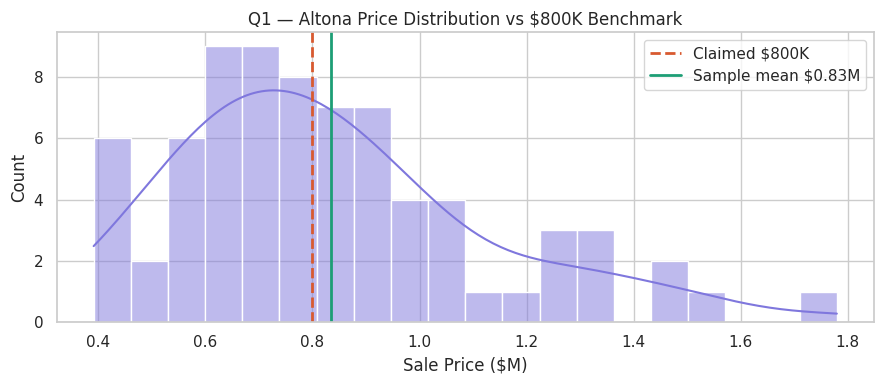

```python
fig, ax = plt.subplots(figsize=(9, 4))
data = altona / 1e6
sns.histplot(data, bins=20, kde=True, ax=ax, color="#7F77DD")
ax.axvline(0.8, color="#D85A30", lw=2, ls="--", label="Claimed $800K")
ax.axvline(data.mean(), color="#1D9E75", lw=2, ls="-", label=f"Sample mean ${data.mean():.2f}M")
ax.set_xlabel("Sale Price ($M)")
ax.set_ylabel("Count")
ax.set_title("Q1 — Altona Price Distribution vs $800K Benchmark")
ax.legend()
plt.tight_layout()
plt.show()
```

```python
print("Chart: Q1 — Histogram with KDE")
print("Description: Distribution of Altona sale prices. Red dashed = claimed $800K; green = actual sample mean. Overlap shows why H0 is not rejected.")
```

```
Chart: Q1 — Histogram with KDE
Description: Distribution of Altona sale prices. Red dashed = claimed $800K; green = actual sample mean. Overlap shows why H0 is not rejected.
```